# FoodHub Data Analysis

### Context

The number of restaurants in New York is increasing day by day. Lots of students and busy professionals rely on those restaurants due to their hectic lifestyles. Online food delivery service is a great option for them. It provides them with good food from their favorite restaurants. A food aggregator company FoodHub offers access to multiple restaurants through a single smartphone app.

The app allows the restaurants to receive a direct online order from a customer. The app assigns a delivery person from the company to pick up the order after it is confirmed by the restaurant. The delivery person then uses the map to reach the restaurant and waits for the food package. Once the food package is handed over to the delivery person, he/she confirms the pick-up in the app and travels to the customer's location to deliver the food. The delivery person confirms the drop-off in the app after delivering the food package to the customer. The customer can rate the order in the app. The food aggregator earns money by collecting a fixed margin of the delivery order from the restaurants.

### Objective

The food aggregator company has stored the data of the different orders made by the registered customers in their online portal. They want to analyze the data to get a fair idea about the demand of different restaurants which will help them in enhancing their customer experience. Suppose you are hired as a Data Scientist in this company and the Data Science team has shared some of the key questions that need to be answered. Perform the data analysis to find answers to these questions that will help the company to improve the business.

### Data Description

The data contains the different data related to a food order. The detailed data dictionary is given below.

### Data Dictionary

- order_id: Unique ID of the order
- customer_id: ID of the customer who ordered the food
- restaurant_name: Name of the restaurant
- cuisine_type: Cuisine ordered by the customer
- cost: Cost of the order
- day_of_the_week: Indicates whether the order is placed on a weekday or weekend (The weekday is from Monday to Friday and the weekend is Saturday and Sunday)
- rating: Rating given by the customer out of 5
- food_preparation_time: Time (in minutes) taken by the restaurant to prepare the food. This is calculated by taking the difference between the timestamps of the restaurant's order confirmation and the delivery person's pick-up confirmation.
- delivery_time: Time (in minutes) taken by the delivery person to deliver the food package. This is calculated by taking the difference between the timestamps of the delivery person's pick-up confirmation and drop-off information

### Let us start by importing the required libraries

```python
# import libraries for data manipulation
import numpy as np
import pandas as pd

# import libraries for data visualization
import matplotlib.pyplot as plt
import seaborn as sns
```

### Understanding the structure of the data

```python
# connecting google colab with drive
from google.colab import drive
drive.mount('/content/drive')
```

```python
# read the data
df = pd.read_csv("/content/drive/MyDrive/Colab Notebooks/foodhub_order.csv")
# returns the first 10 rows
df.head(10)
```

|  | order_id | customer_id | restaurant_name | cuisine_type | cost_of_the_order | day_of_the_week | rating | food_preparation_time | delivery_time |
| --- | --- | --- | --- | --- | --- | --- | --- | --- | --- |
| 0 | 1477147 | 337525 | Hangawi | Korean | 30.75 | Weekend | Not given | 25 | 20 |
| 1 | 1477685 | 358141 | Blue Ribbon Sushi Izakaya | Japanese | 12.08 | Weekend | Not given | 25 | 23 |
| 2 | 1477070 | 66393 | Cafe Habana | Mexican | 12.23 | Weekday | 5 | 23 | 28 |
| 3 | 1477334 | 106968 | Blue Ribbon Fried Chicken | American | 29.20 | Weekend | 3 | 25 | 15 |
| 4 | 1478249 | 76942 | Dirty Bird to Go | American | 11.59 | Weekday | 4 | 25 | 24 |
| 5 | 1477224 | 147468 | Tamarind TriBeCa | Indian | 25.22 | Weekday | 3 | 20 | 24 |
| 6 | 1477894 | 157711 | The Meatball Shop | Italian | 6.07 | Weekend | Not given | 28 | 21 |
| 7 | 1477859 | 89574 | Barbounia | Mediterranean | 5.97 | Weekday | 3 | 33 | 30 |
| 8 | 1477174 | 121706 | Anjappar Chettinad | Indian | 16.44 | Weekday | 5 | 21 | 26 |
| 9 | 1477311 | 39705 | Bukhara Grill | Indian | 7.18 | Weekday | 5 | 29 | 26 |

#### Observations:

The DataFrame has 9 columns as mentioned in the Data Dictionary. Data in each row corresponds to the order placed by a customer.

### How many rows and columns are present in the data?

```python
# extracting rows and columns
df.shape
```

```
(1898, 9)
```

#### Observations:

There are 1898 rows and 9 columns in data

### What are the datatypes of the different columns in the dataset?

```python
# concise summary of the DataFrame
df.info()
```

```
<class 'pandas.core.frame.DataFrame'>
RangeIndex: 1898 entries, 0 to 1897
Data columns (total 9 columns):
 #   Column                 Non-Null Count  Dtype
---  ------                 --------------  -----
 0   order_id               1898 non-null   int64
 1   customer_id            1898 non-null   int64
 2   restaurant_name        1898 non-null   object
 3   cuisine_type           1898 non-null   object
 4   cost_of_the_order      1898 non-null   float64
 5   day_of_the_week        1898 non-null   object
 6   rating                 1898 non-null   object
 7   food_preparation_time  1898 non-null   int64
 8   delivery_time          1898 non-null   int64
dtypes: float64(1), int64(4), object(4)
memory usage: 133.6+ KB
```

#### Observations:

No null values are in dataset

### statistical summary of the data. What is the minimum, average, and maximum time it takes for food to be prepared once an order is placed?

```python
df.describe().T
```

|  | count | mean | std | min | 25% | 50% | 75% | max |
| --- | --- | --- | --- | --- | --- | --- | --- | --- |
| order_id | 1898.0 | 1.477496e+06 | 548.049724 | 1476547.00 | 1477021.25 | 1477495.50 | 1.477970e+06 | 1478444.00 |
| customer_id | 1898.0 | 1.711685e+05 | 113698.139743 | 1311.00 | 77787.75 | 128600.00 | 2.705250e+05 | 405334.00 |
| cost_of_the_order | 1898.0 | 1.649885e+01 | 7.483812 | 4.47 | 12.08 | 14.14 | 2.229750e+01 | 35.41 |
| food_preparation_time | 1898.0 | 2.737197e+01 | 4.632481 | 20.00 | 23.00 | 27.00 | 3.100000e+01 | 35.00 |
| delivery_time | 1898.0 | 2.416175e+01 | 4.972637 | 15.00 | 20.00 | 25.00 | 2.800000e+01 | 33.00 |

```python
# Extract the minimum, average (mean), and maximum values
min_preparation_time = df["food_preparation_time"].min()
avg_preparation_time = df["food_preparation_time"].mean()
max_preparation_time = df["food_preparation_time"].max()

# Print the results
print(f"Minimum Food Preparation Time: {min_preparation_time} minutes")
print(f"Average Food Preparation Time: {avg_preparation_time:.2f} minutes")
print(f"Maximum Food Preparation Time: {max_preparation_time} minutes")
```

```
Minimum Food Preparation Time: 20 minutes
Average Food Preparation Time: 27.37 minutes
Maximum Food Preparation Time: 35 minutes
```

```python
# Extract the minimum, average (mean), and maximum values
min_delivery_time = df["delivery_time"].min()
avg_delivery_time = df["delivery_time"].mean()
max_delivery_time = df["delivery_time"].max()

# Print the results
print(f"Minimum Food delivery Time: {min_delivery_time} minutes")
print(f"Average Food delivery Time: {avg_delivery_time:.2f} minutes")
print(f"Maximum Food delivery Time: {max_delivery_time} minutes")
```

```
Minimum Food delivery Time: 15 minutes
Average Food delivery Time: 24.16 minutes
Maximum Food delivery Time: 33 minutes
```

#### Observations:

Since Rating is a neumerical column but it is not in above describe table hence there is something odd in Rating column. on inspecting i got there are some orders which are not rated

### How many orders are not rated?

```python
# Count the occurrences of different ratings
rating_counts = df["rating"].value_counts()

# Check if "Not given" is in the rating counts and get its count if present
not_rated_count = rating_counts.get("Not given")

# Print the number of orders not rated
print("Number of orders not rated:",not_rated_count)
```

```
Number of orders not rated: 736
```

### Exploratory Data Analysis (EDA)

### Explore all the variables and provide observations on their distributions.

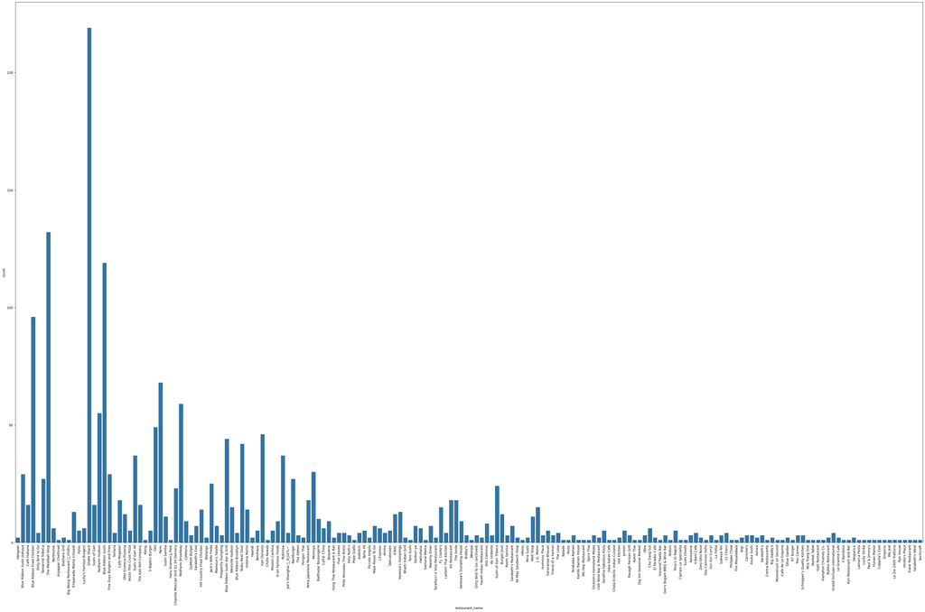

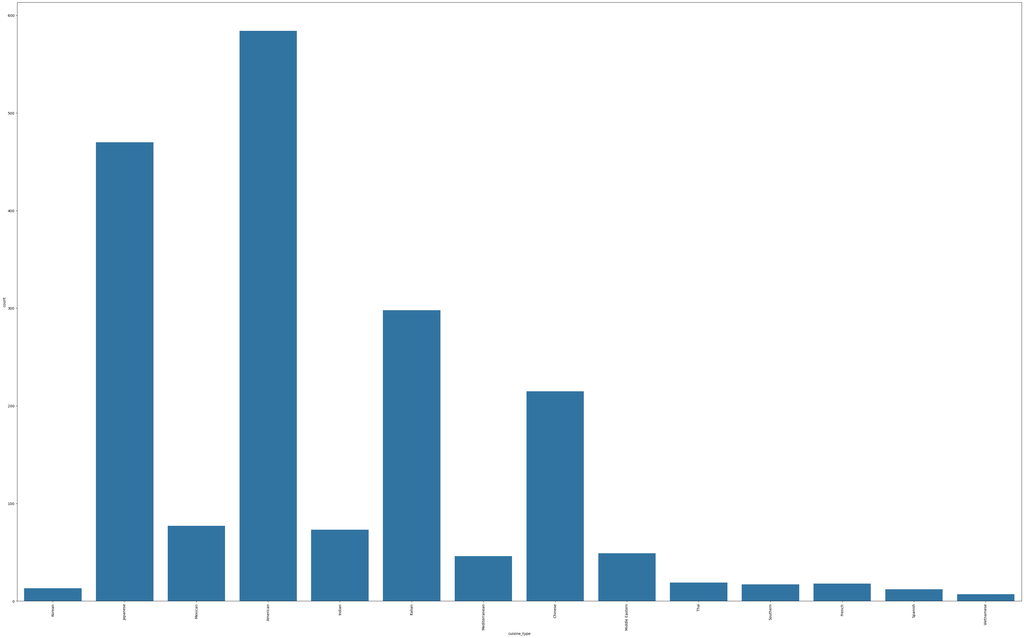

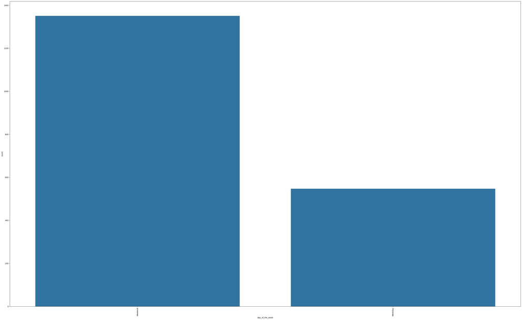

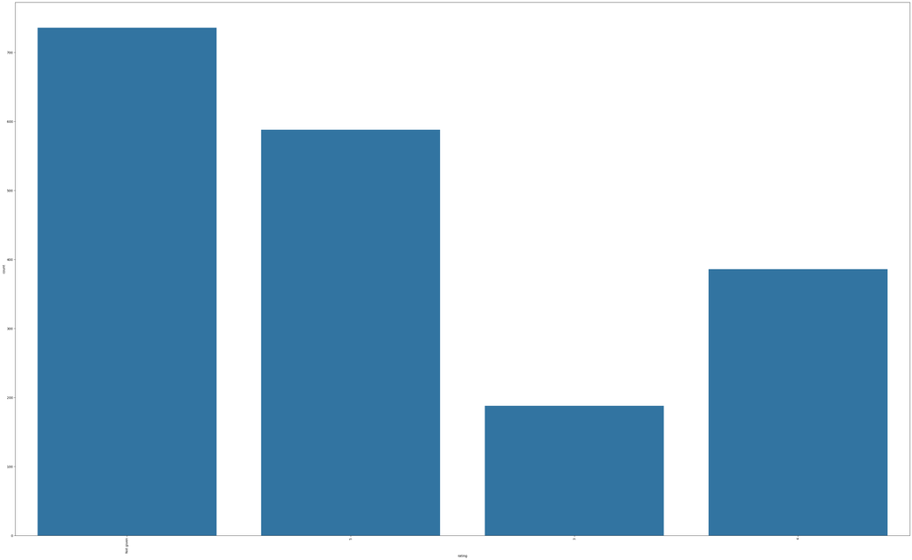

```python
# univariate analysis of catagorical variables
import warnings
warnings.filterwarnings("ignore")


catagorical_var = ["restaurant_name","cuisine_type","day_of_the_week","rating"]

for i in catagorical_var:
    plt.subplots(figsize=(50, 30))
    plt.xticks(rotation=90)
    sns.countplot(data=df,x=i)
    plt.show()
```

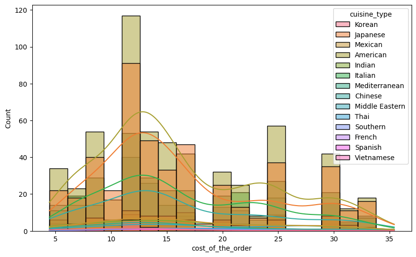

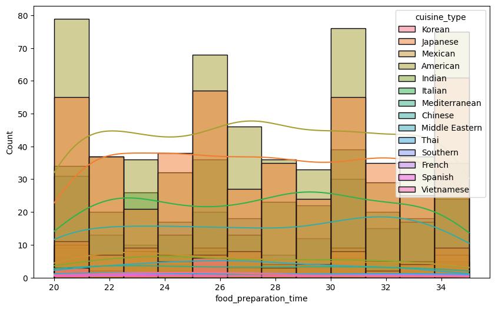

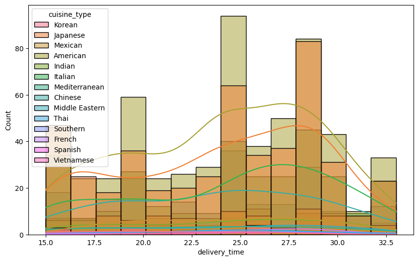

```python
# univariate analysis of neumerical variables
neumerical_var = ["cost_of_the_order","food_preparation_time","delivery_time"]

for i in neumerical_var:
    plt.subplots(figsize=(10, 6))
    sns.histplot(data=df,x=i,kde=True,hue="cuisine_type")
    plt.show()
```

### Which are the top 5 restaurants in terms of the number of orders received ?

```python
restaurant_order_counts = df['restaurant_name'].value_counts()
top_5_restaurants = restaurant_order_counts.head(5)
print("Top 5 restaurants in terms of number of orders:")
print(top_5_restaurants)
```

```
Top 5 restaurants in terms of number of orders:
Shake Shack                  219
The Meatball Shop            132
Blue Ribbon Sushi            119
Blue Ribbon Fried Chicken     96
Parm                          68
Name: restaurant_name, dtype: int64
```

#### Observations:

### Top five restaurants in terms of number of orders are : Shake Shack,The Meatball Shop,Blue Ribbon Sushi,Blue Ribbon Fried Chicken, Parm.

### Which is the most popular cuisine on weekends?

```python
# Filtering the data for orders placed on weekends
weekend_orders = df[df['day_of_the_week'] == 'Weekend']

# Get the most popular cuisine on weekends using value_counts
most_popular_cuisine_weekends = weekend_orders['cuisine_type'].value_counts().idxmax()

print("The most popular cuisine on weekends is:", most_popular_cuisine_weekends)
```

```
The most popular cuisine on weekends is: American
```

### What percentage of the orders cost more than 20 dollars?

```python
# Write the code here
total_orders = len(df)

orders_greater_than_20 = len(df[df["cost_of_the_order"]>20])

percentage = (orders_greater_than_20/total_orders)*100
round_percentage = round(percentage,2)
print(f"percentage of orders cost more than 20 dollars is {round_percentage} %")
```

```
percentage of orders cost more than 20 dollars is 29.24 %
```

#### Observations: More than 70 percent orders cost less than 20 $

### What is the mean order delivery time?

```python
mean_delivery_time = round(df["delivery_time"].mean(),2)
print(f"mean order delivery time is {mean_delivery_time} minutes ")
```

```
mean order delivery time is 24.16 minutes
```

### The company has decided to give 20% discount vouchers to the top 3 most frequent customers. Find the IDs of these customers and the number of orders they placed.

```python
# Calculate the frequency of each customer's orders
customer_order_counts = df['customer_id'].value_counts()

# Get the top 3 most frequent customers
top_customers = customer_order_counts.head(3)

# Display the IDs of the top 3 customers and the number of orders they placed
print("Top 3 most frequent customers and their order counts:")
for customer_id, order_count in top_customers.items():
    print(f"Customer ID: {customer_id}, Number of Orders: {order_count}")
```

```
Top 3 most frequent customers and their order counts:
Customer ID: 52832, Number of Orders: 13
Customer ID: 47440, Number of Orders: 10
Customer ID: 83287, Number of Orders: 9
```

#### Observations: Top 3 most frequent customers and :

Customer ID: 52832, Customer ID: 47440, Customer ID: 83287.

### Perform a multivariate analysis to explore relationships between the important variables in the dataset.

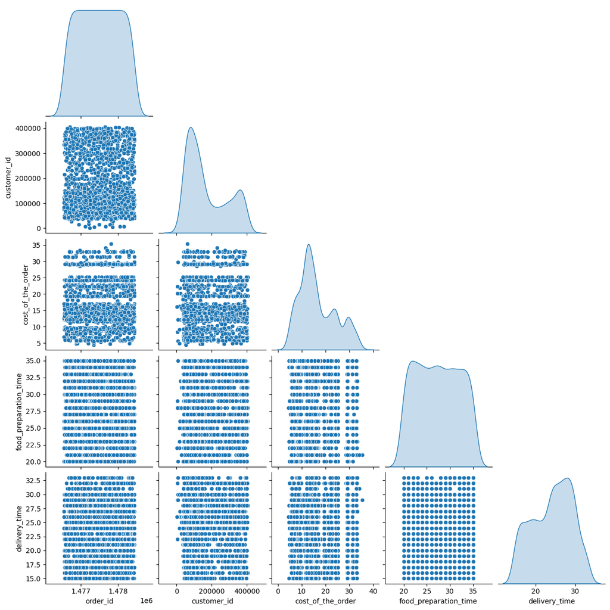

```python
sns.pairplot(data=df,diag_kind="kde",corner =True)
```